# Neotoma Vertebrates Overview

Nick Hoffman

2025-10-01

# Space

## Spatial Coverage

There are 5371 vertebrate fauna datasets in Neotoma. Below is a map of all the sites in Neotoma corresponding to these datasets, colored by the constituent database to which they correspond.

[interactive chart not shown]

The datasets associated with the insect database or which associated with no database (i.e., NA) are:

| datasetid | collectionunitid | siteid | sitename | databasename |
| --- | --- | --- | --- | --- |
| 16232 | 11956 | 10535 | Rio Dell Formation |  |
| 24784 | 18109 | 16063 | Yaworski [AfHi-21] |  |
| 26667 | 19382 | 16714 | Lavoie [DbEj-11] |  |
| 38910 | 26881 | 21439 | Little Eldorado Creek [AKLIV-VP] |  |
| 38913 | 26882 | 21439 | Little Eldorado Creek [AKLIV-VP] |  |
| 38915 | 26883 | 21439 | Little Eldorado Creek [AKLIV-VP] |  |
| 38917 | 26884 | 21439 | Little Eldorado Creek [AKLIV-VP] |  |
| 40800 | 28301 | 23584 | Fort Rodd Hill [DcRu-78] |  |
| 40925 | 28373 | 23655 | Fort Albany [Fishing Creek] |  |
| 40926 | 28373 | 23655 | Fort Albany [Fishing Creek] |  |

[output cut: 2 more lines]

## Spatial Precision

The spatial precision of Neotoma data refers to how closely a site’s location as designated in Neotoma maps on to the site’s actual location. 5063 of the vertebrate datasets in Neotoma are point locations, while 305 are bounding boxes. According to the [Neotoma Manual](https://neotoma-manual.readthedocs.io/en/latest/tables_site.html#sites), “the lat-long box can be used either to circumscribe the areal extent of a site or to provide purposeful imprecision to the site location.” In other words, there is an ambiguity inherent to the use of bounding boxes in Neotoma. Some are for designating the full extent of a lake, while others are used for fuzzing the coordinates of sensitive sites. Adding to this confusion is the fact that different constituent databases have historically addressed spatial precision differently. FAUNMAP, which contains most (n=4851) of Neotoma’s vertebrate data, has many sites that are designated as points but which actually are fuzzed to some extent. The original FAUNMAP database had metadata on the precision of its sites, but Neotoma no longer does. See this [page section](https://hoffmanick.github.io/eos/neoHomo.html#6_Are_the_coordinates_for_any_sites_in_Neotoma_fuzzed) for an attempt at matching Neotoma’s FAUNMAP data to original FAUNMAP precision metadata.

# Time

## Chronologies

Of the 5371 vertebrate fauna datasets in Neotoma, there are a plurality, 2346 datasets, which only have a chronology in raw radiocarbon years. There are another 1197 which have both a raw radiocarbon chronology and a calibrated chronology (almost all of these are “Calibrated Radiocarbon Years”; three are “Calendar Years BP”).

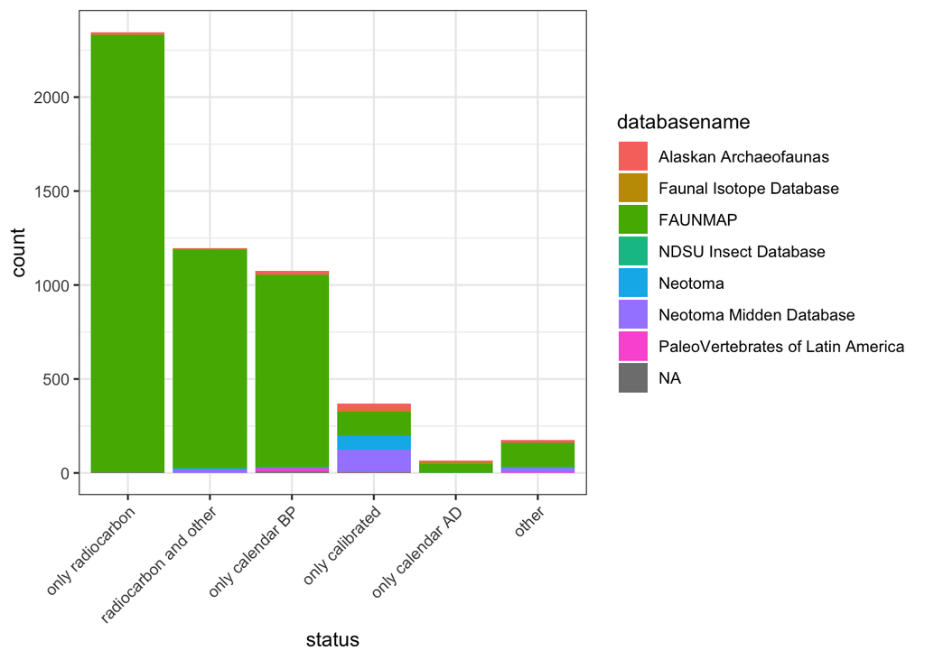

To determine temporal coverage of the vertebrate fauna datasets, I had to select chronologies for each dataset. If a dataset only had a single chronology, I chose that. For the rest, this was the order of preference:

- Syverson-Blois bounds
- FAUNMAP 2.1
- Calibrated
- Neotoma 2
- FAUNMAP 1.1

For the remaining 23 datasets, I chose a chronology randomly. I used the reliableagespan values associated with this [API](https://api.neotomadb.org/v2.0/data/datasets/100/chronologies) to get older and younger bounds associated with a dataset. Four of the FAUNMAP 1.1 datasets (IDs = 6450,6861,6972,7833) had NA older and younger bounds, so I removed those.

Below is a table of the ages of the chronologies I chose.

| chronologyName | agetype | n |
| --- | --- | --- |
| FAUNMAP 1.1 | Radiocarbon years BP | 1966 |
| Syverson-Blois: bounds | Calibrated radiocarbon years BP | 1560 |
| Faunmap 2.1 | Calendar years BP | 646 |
| Faunmap 2.1 | Radiocarbon years BP | 366 |
| FAUNMAP 1.1 | Calendar years BP | 356 |
| Neotoma 1 | Calibrated radiocarbon years BP | 59 |
| Calibrated Ages | Calibrated radiocarbon years BP | 18 |
| NEOTOMA 1 | Calibrated radiocarbon years BP | 14 |
| PaVeLA 1 | Calendar years BP | 12 |
| Neotoma 2 | Calibrated radiocarbon years BP | 10 |

[output cut: 158 more lines]

## Coverage

Given these chronologies, we found that most datasets (n= 3246) are from the Holocene epoch, nearly 1000 span the Holocene and Pleistocene, and nearly another 1000 are within the Pleistocene, with fewer further back in time.

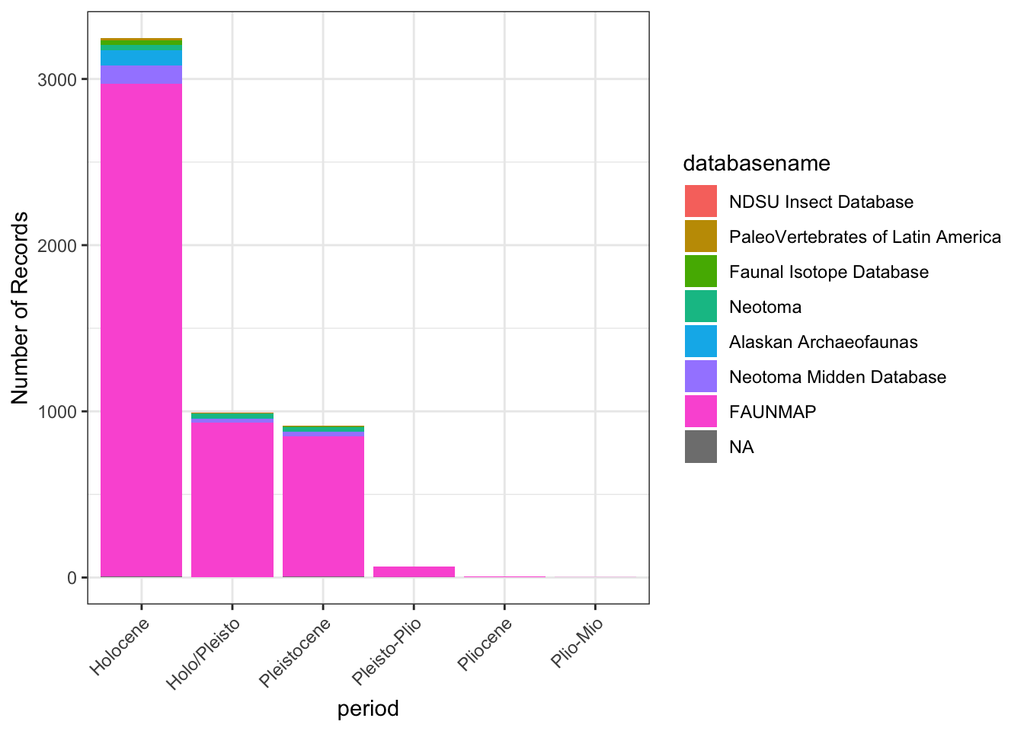

## Temporal Precision

These graphs show dataset-level temporal precision. For datasets with an age type of calendar years AD/BC, I converted to BP. The first is colored by database name, and the second is colored by the chronology type.

[interactive chart not shown]

And this graph shows sample-level temporal precision.

[interactive chart not shown]

## Uploads Over Time

Below you can see when a dataset was originally uploaded to Neotoma, based on the recdatecreated field for the dataset.

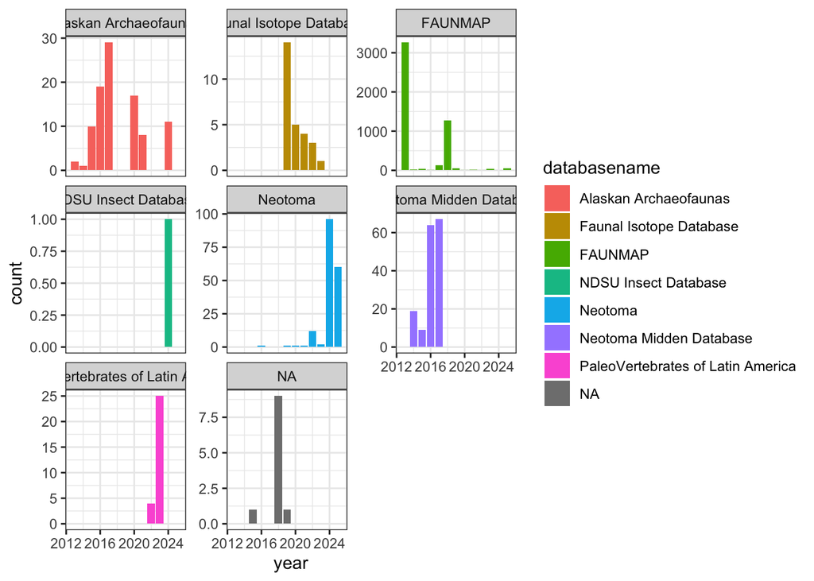

# Taxonomy

The below table shows all the taxa observed in vertebrate fauna datasets ranked by the number of datasets in which they occur. The graph below that is a rank-abundance curve.

| taxonid | variablename | n |
| --- | --- | --- |
| 5856 | Aves | 1280 |
| 6332 | Odocoileus virginianus | 1085 |
| 6461 | Reptilia | 1005 |
| 6355 | Osteichthyes | 923 |
| 5928 | Castor canadensis | 857 |
| 6600 | Sylvilagus sp. | 777 |
| 6452 | Procyon lotor | 762 |
| 6331 | Odocoileus sp. | 714 |
| 5920 | Canis sp. | 662 |
| 5874 | Bison sp. | 588 |

[output cut: 2873 more lines]

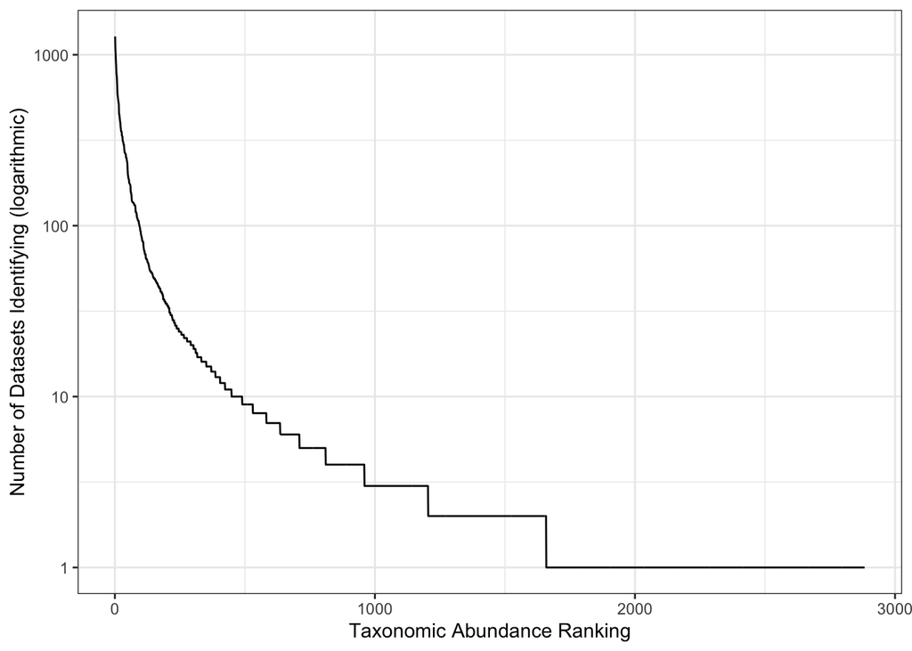

## Taxonomic Precision

I harmonized the data from vertebrate fauna datasets in Neotoma with a table that Val and Jessica made which also described the taxonomic precision of the identification. That table captured 567 of the 2721 taxa described in Neotoma vertebrate fauna datasets (20.83%), and 32,965 of the 79,069 of the observations in the datasets (41.70%).

Following harmonization with Jessica and Val’s table, and dropping those taxa which weren’t represented in it, here is a summary of the precision of the vertebrate fauna data overall:

| uncertainty | n |
| --- | --- |
| species | 20249 |
| genus | 9122 |
| cf_species | 1894 |
| family | 872 |
| order | 380 |
| species_2 | 281 |
| cf_genus | 135 |
| genus_2 | 21 |
| genus_4 | 3 |
| subgenus | 3 |

[output cut: 2 more lines]

I made an uncertainty metric to measure site-level precision. I assigned a certainty score to each rank, such that species = 1, genus = 2, family = 3, and in-between values get half points:

| values | precision |
| --- | --- |
| 4 | order |
| 3.5 | cf_family |
| 3 | family |
| 2.5 | cf_genus |
| 2.5 | genus_2 |
| 2.5 | genus_4 |
| 2.5 | tribe |
| 2 | genus |
| 1.5 | cf_species |
| 1.5 | species_2 |

[output cut: 2 more lines]

The map below shows the spatial distribution of taxonomic richness and uncertainty in separate layers.

[interactive chart not shown]

Below is a graph that shows how precision has evolved over time. There’s no obvious change over time.

[interactive chart not shown]

## Taxonomic Coverage

Below are maps of two key species from every order of mammals. The following orders are not represented:

- Primates (except for *Homo*)
- Diprotodonts (no Australian sites)
- Dasyuromorphs (no Australian sites)
- Peramelemorphs (no Australian sites)
- Afrosoricida (no African sites)
- Macroscelidea (no African sites)
- Scandentia (no southeast Asian sites)
- Paucituberculata (few South American sites)
- Pholidota (few subtropical African and Asian sites)
- Hyracoidea
- Monotremes
- Dermoptera
- Notoryctemorphia
- Microbiotheria
- Tubulidentata

I also didn’t consider extinct orders. I think *Psittacotherium multifragum* may be from an extinct order.

### Rodents: Microtus ochrogaster

[interactive chart not shown]

### Rodents: Marmota flaviventris

[interactive chart not shown]

### Bats: Eptesicus fuscus

[interactive chart not shown]

### Bats: Myotis sp.

[interactive chart not shown]

### Eulipotyphla: Scalopus aquaticus

[interactive chart not shown]

### Eulipotyphla: Blarina brevicauda

[interactive chart not shown]

### Artiodactyls: Mylohyus fossilis

[interactive chart not shown]

### Artiodactyls: Camelops

[interactive chart not shown]

### Carnivorans: Urocyon cinereoargenteus

[interactive chart not shown]

### Carnivorans: Taxidea taxus

[interactive chart not shown]

### Lagomorphs: Sylvilagus floridanus

[interactive chart not shown]

### Lagomorphs: Brachylagus idahoensis

[interactive chart not shown]

### Perissodactyls: Equus conversidens

[interactive chart not shown]

### Perissodactyls: Tapirus veroensis

[interactive chart not shown]

### Proboscideans: Mammut americanum

[interactive chart not shown]

### Proboscideans: Mammuthus sp.

[interactive chart not shown]

### Didelphimorphs: Didelphis virginiana

[interactive chart not shown]

### Didelphimorphs: Didelphis marsupialis

[interactive chart not shown]

### Sirens: Trichechus manatus

[interactive chart not shown]

### Sirens: Trichechidae

[interactive chart not shown]

### Cingulates: Glyptotherium texanum

[interactive chart not shown]

### Cingulates: Dasypus bellus

[interactive chart not shown]

### Pilosa: Megalonyx jeffersonii

[interactive chart not shown]

### Pilosa: Paramylodon harlani

[interactive chart not shown]

I matched taxa in Neotoma to taxa recoded by the Mammal Diversity Database, in order to get information on order, family, and genus for each identification.

The Mammal Diversity Database won’t match taxa starting with ? or cf., or with sp. in the name. It also won’t match names that are cf. with respect to genus or which are two identificatons joined by a slah. I removed those precision markers from the taxa names for the matching process. (I kept the presence or absence of those markers in a new column though, so it’s not lost, but I haven’t used that information in the below visualizations.)

I ended up matching 52,477 observations out of 79,069, and 1325 out of 2721 taxa. There’s a bias toward missing all the extinct species, so you don’t see the pilosa or cingulates from the Americas that you might otherwise. There are also a few nomenclature issues, some of which are amenable to similar adjustments to the certainty marker edits I did above, and some of which reflect synonymy issues.

I surveyed 500 of the unmatched names, and I found that about half were unmatched because nonmammal; about a third were extinct mammals, about 10% were nomenclature issues of one kind or another, and the last 5% I couldn’t figure out why they didn’t match.

For the sake of simplicity, I ignore cf., sp., etc. in my table below. (But I retain that information in the dataframe.)

The graph below shows the representation among taxa matched to the MMD of the various mammal orders.

And below that, the table shows the number of distinct families, genera, and species represented in Neotoma for each order represented.

The reason that sirenia has two families but fewer genera and species is that only one of the Sirenia observations went to species-precision, while the other two only went to family, so I didn’t count those two in the genera and species column. Similarly, proboscideans are not represented in the table but they are in the graph because there were MMD-matched taxa to order-precision for proboscideans, but nothing more precise than that. Of course, Neotoma has a lot of mammut and mammuthus, but those taxa IDs were not matched in the MMD, probably because the MMD seems only to concern itself with extant taxa.

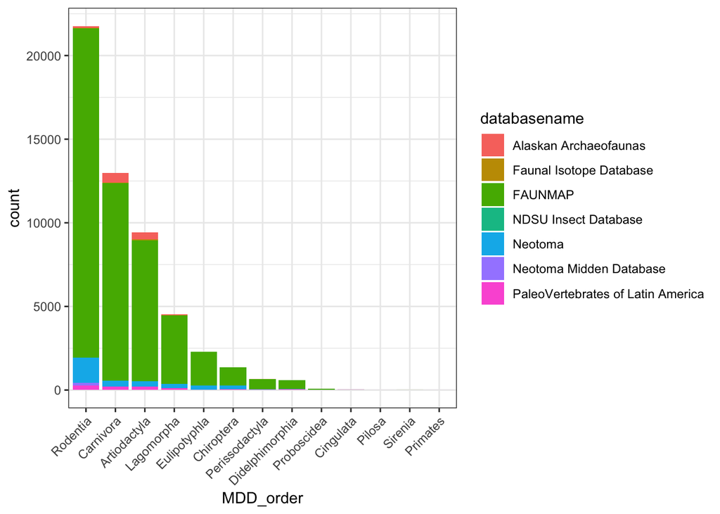

| order | number families | number genera | number species |
| --- | --- | --- | --- |
| Rodentia | 15 | 83 | 190 |
| Artiodactyla | 10 | 29 | 36 |
| Carnivora | 9 | 40 | 65 |
| Chiroptera | 7 | 36 | 60 |
| Lagomorpha | 2 | 5 | 18 |
| Eulipotyphla | 2 | 8 | 30 |
| Perissodactyla | 2 | 2 | 3 |
| Sirenia | 2 | 1 | 1 |
| Didelphimorphia | 1 | 5 | 6 |
| Cingulata | 1 | 1 | 2 |

[output cut: 2 more lines]